# CompBio_LectureNotes_03212017

Emily Mikucki

3/21/2017

### **Guest Lecture: Brandon Ogbunu**

- Darwin’s Dangerous Idea –> Dennett’s Calculator (Wrongulator); doesn’t mask ignaorance, is a means to unmasking ignorance
- Modelling = understanding the pieces that will help you understand the larger picture

#### **Mathematical model**

- focuses on specific quantitative features of hte scenario, ignores others
- mathematical description of a scenario or situation from the real-world
- simplification, abstraction
- involves hypotheses that can be tested against real data and refined if desired
- improved understanding of real-world scenario

#### **Why study epidemic models?**

- supplement statistical extrapolations
- learn more about the qualitative dynamics of a disease
- test hypotheses about (for example) prevention strategies, disease transmission, significant charactersitics, etc.

#### **Different kinds of models:**

- deterministic
- discrete-time
- stochastic
- individual-based model (negative: if population is large you get “average” anyways…)
- network models

#### **SIR epidemic model**

- consider a disease spread by contact with infected individuals
- define rate of change (susceptible, infected, recovered…)

#### **Ordinary differential equations**

- pedator prey models

#### **Basic differential equation model in R**

- Use EpiModel

#### Basic SI Model: Starting with a basic Susceptible-Infected (SI) disease model in which there is random mixing within the population

```r
#install.packages("EpiModel", dependencies = TRUE)
library(EpiModel)
param <- param.dcm(inf.prob = 0.2, act.rate = 0.25)
init <- init.dcm(s.num = 500, i.num = 1) #sets the transmission probability per act
control <- control.dcm(type = "SI", nsteps = 500) #collects other structural model controls like the model type and number of time steps for the simulation

mod <- dcm(param, init, control)
mod
```

```
## EpiModel Simulation
## =======================
## Model class: dcm
##
## Simulation Summary
## -----------------------
## Model type: SI
## No. runs: 1
## No. time steps: 500
## No. groups: 1
##
## Model Parameters
## -----------------------
## inf.prob = 0.2
## act.rate = 0.25
##
## Model Output
## -----------------------
## Variables: s.num i.num si.flow num
```

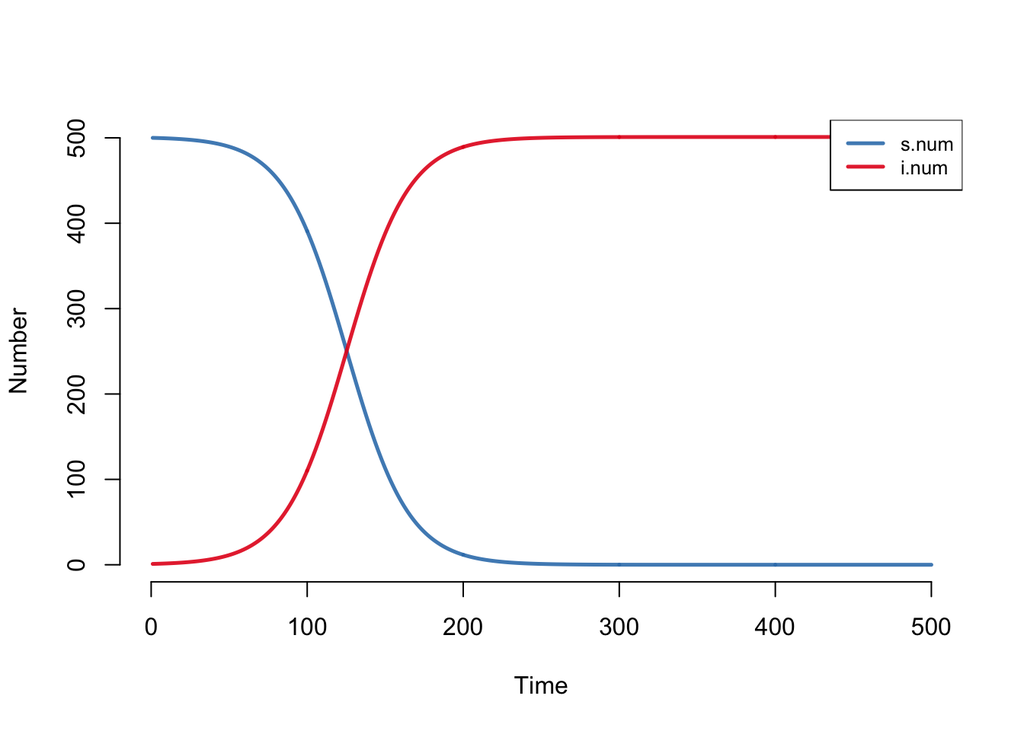

```r
plot(mod)
```

```r
summary(mod, at = 150) #Determines num susceptible and num infected @ time 150
```

```
## EpiModel Summary
## =======================
## Model class: dcm
##
## Simulation Summary
## -----------------------
## Model type: SI
## No. runs: 1
## No. time steps:
## No. groups: 1
##
## Model Statistics
## ------------------------------
## Time: 150     Run: 1
## ------------------------------
##                 n    pct
## Suscept.  112.845  0.225
## Infect.   388.155  0.775
## Total     501.000  1.000
## S -> I      4.311     NA
## ------------------------------
```

#### SIR Model with Demography: In a Susceptible-Infectious-Recovered (SIR) model, infected individuals transition from disease into a life-long recovered state in which they are never again susceptible

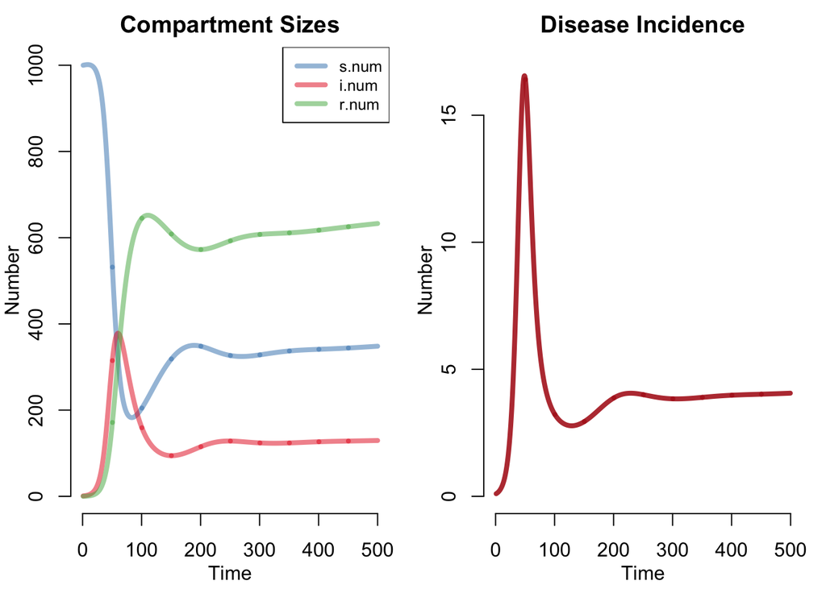

```r
#parameters for the recovery rate, birth rate, and state-specific death rates are entered
param <- param.dcm(inf.prob = 0.2, act.rate = 1, rec.rate = 1/20,
                   b.rate = 1/95, ds.rate = 1/100, di.rate = 1/80, dr.rate = 1/100)
init <- init.dcm(s.num = 1000, i.num = 1, r.num = 0) #specify the number of initially recovered
control <- control.dcm(type = "SIR", nsteps = 500, dt = 0.5) #obtain model results in fractional time units
mod <- dcm(param, init, control)

par(mar = c(3.2, 3, 2, 1), mgp = c(2, 1, 0), mfrow = c(1, 2)) #used to change some default graphical options
plot(mod, popfrac = FALSE, alpha = 0.5,
     lwd = 4, main = "Compartment Sizes")
plot(mod, y = "si.flow", lwd = 4, col = "firebrick",
     main = "Disease Incidence", leg = "n") #This is really cool! Plot the prevalences for all compartments in the model, but in the right plot we override that using the y argument to specify that disease incidence
```

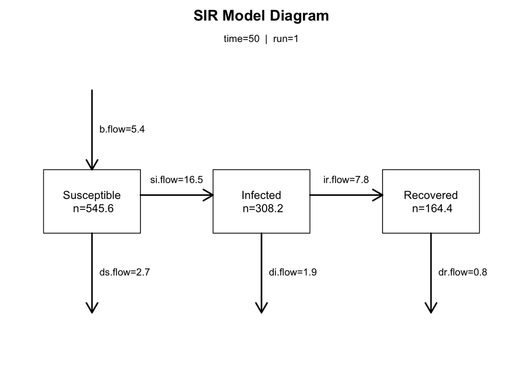

```r
par(mfrow = c(1, 1))
comp_plot(mod, at = 50, digits = 1) #The plot shows the three state sizes and flows at t50t50.
```

#### Change the Parameters of SIR Model with Demography :

```r
param <- param.dcm(inf.prob = 0.5, act.rate = 1, rec.rate = 5/20,
                   b.rate = 5/95, ds.rate = 5/100, di.rate = 5/80, dr.rate = 5/100)
init <- init.dcm(s.num = 1000, i.num = 1, r.num = 0)
control <- control.dcm(type = "SIR", nsteps = 500, dt = 0.5)
 mod <- dcm(param, init, control)
mod
```

```
## EpiModel Simulation
## =======================
## Model class: dcm
##
## Simulation Summary
## -----------------------
## Model type: SIR
## No. runs: 1
## No. time steps: 500
## No. groups: 1
##
## Model Parameters
## -----------------------
## inf.prob = 0.5
## act.rate = 1
## rec.rate = 0.25
## b.rate = 0.05263158
## ds.rate = 0.05
## di.rate = 0.0625
## dr.rate = 0.05
##
## Model Output
## -----------------------
## Variables: s.num i.num r.num si.flow ir.flow b.flow
## ds.flow di.flow dr.flow num
```

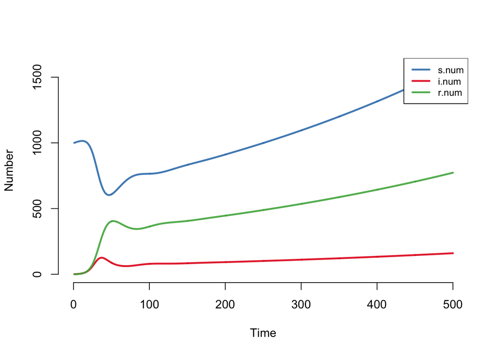

```r
plot(mod)
```

```r
summary(mod, at = 150)
```

```
## EpiModel Summary
## =======================
## Model class: dcm
##
## Simulation Summary
## -----------------------
## Model type: SIR
## No. runs: 1
## No. time steps:
## No. groups: 1
##
## Model Statistics
## ------------------------------
## Time: 150     Run: 1
## ------------------------------
##                    n    pct
## Suscept.     832.637  0.630
## Infect.       83.843  0.063
## Recov.       406.060  0.307
## Total       1322.539  1.000
## S -> I        13.204     NA
## I -> R        10.486     NA
## Birth ->      34.820     NA
## S Death ->    20.826     NA
## I Death ->     2.622     NA
## R Death ->    10.156     NA
## ------------------------------
```

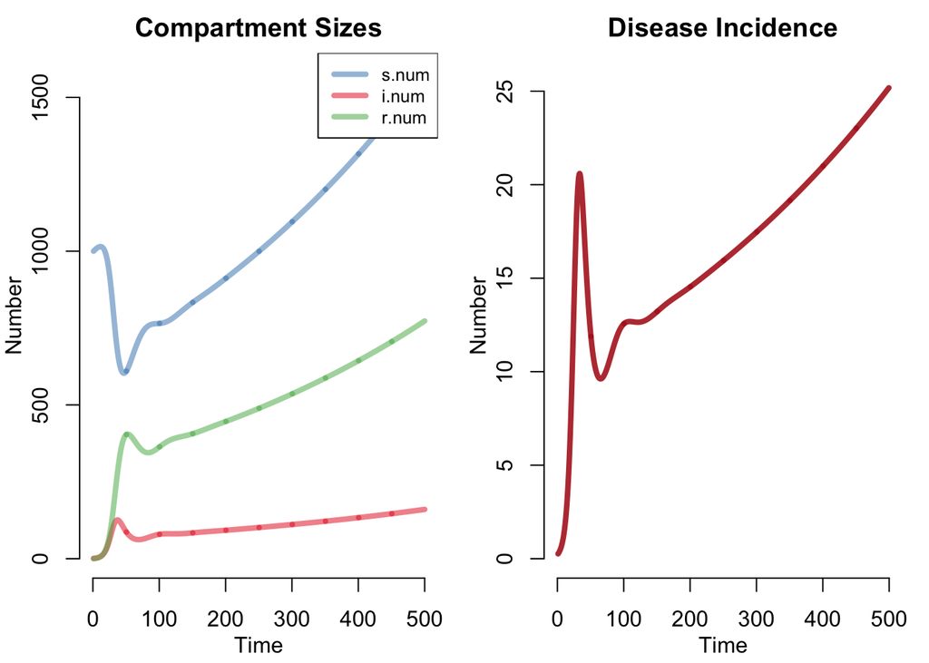

```r
par(mar = c(3.2, 3, 2, 1), mgp = c(2, 1, 0), mfrow = c(1, 2)) #used to change some default graphical options
plot(mod, popfrac = FALSE, alpha = 0.5,
     lwd = 4, main = "Compartment Sizes")
plot(mod, y = "si.flow", lwd = 4, col = "firebrick",
     main = "Disease Incidence", leg = "n")
```

####SIS Model with Sensitivity Analyses